# R Notebook

```r
owner<-df
owner[] <- lapply(df, function(x) {
    if(is.character(x)) replace(x, is.na(x), Mode(na.omit(x)))
})
```

```r
df$ownerChange<-owner$ownerChange
```

```r
str(df)
```

```
## 'data.frame':    301 obs. of  23 variables:
##  $ OC             : chr  "open" "open" "open" "open" ...
##  $ bedCount       : num  175 410 468 353 196 243 213 250 280 55 ...
##  $ revenue1       : num  4.22e+09 1.29e+10 1.00e+09 7.25e+10 4.90e+10 ...
##  $ salescost1     : num  0.00 2.01e+09 5.15e+08 0.00 0.00 ...
##  $ sga1           : num  3.96e+09 1.03e+10 4.47e+08 7.07e+10 4.77e+10 ...
##  $ salary1        : num  2.03e+09 5.65e+09 2.96e+08 3.18e+10 2.45e+10 ...
##  $ noi1           : num  1.57e+07 2.70e+08 7.62e+04 5.06e+08 1.12e+08 ...
##  $ noe1           : num  1.52e+07 5.12e+08 3.00e+04 1.26e+09 1.42e+09 ...
##  $ interest1      : num  1.32e+07 1.87e+08 0.00 1.20e+09 1.31e+09 ...
##  $ ctax1          : num  3.16e+07 7.85e+07 0.00 1.74e+08 0.00 ...
##  $ profit1        : num  2.25e+08 2.10e+08 4.19e+07 9.03e+08 8.07e+07 ...
##  $ liquidAsset1   : num  1.01e+09 3.54e+09 2.72e+08 1.30e+10 6.32e+09 ...
##  $ quickAsset1    : num  9.98e+08 3.41e+09 2.54e+08 1.15e+10 5.87e+09 ...
##  $ receivableS1   : num  4.70e+08 6.98e+08 8.10e+06 0.00 4.10e+09 ...
##  $ inventoryAsset1: num  1.50e+07 1.15e+08 1.88e+07 1.51e+09 4.44e+08 ...
##  $ nonCAsset1     : num  2.51e+09 1.14e+10 1.20e+08 4.32e+10 4.37e+10 ...
##  $ tanAsset1      : num  2.36e+09 1.05e+10 1.20e+08 3.83e+10 4.33e+10 ...
##  $ OnonCAsset1    : num  1.43e+08 3.41e+08 0.00 3.95e+09 2.22e+08 ...
##  $ receivableL1   : num  0 251680 0 0 0 ...
##  $ debt1          : num  6.83e+08 8.77e+09 9.24e+07 4.24e+10 4.99e+10 ...
##  $ surplus1       : num  1.50e+09 1.27e+09 0.00 8.64e+09 9.03e+09 ...
##  $ employee1      : num  62 801 234 663 206 397 221 489 243 370 ...
##  $ ownerChange    : chr  "same" "same" "same" "same" ...
```

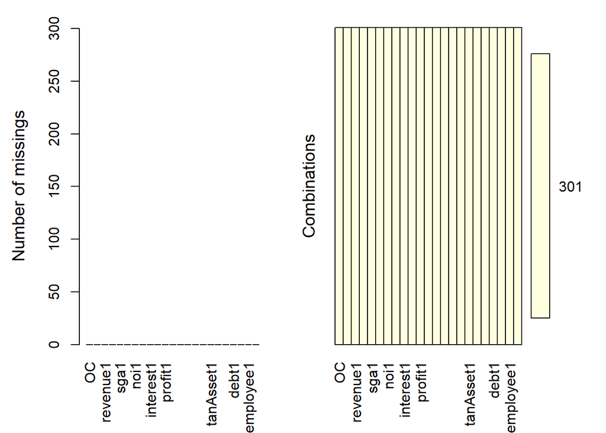

```r
aggr(df,prop=F,numbers=T,col=c('lightyellow','pink'))
```

#문제 4. 변수 ‘OC(병원 개/폐업 여부)’를 타겟 변수로 사용하기 위해 “open”을 1, “close”를 0으로 바꾸세요

```r
df$OC<-gsub("open",1,df$OC)
df$OC<-gsub("close",0,df$OC)
#df$OC<-revalue(df$OC, c("open"=1,"close"=0))

df
```

| OC | bedCount | revenue1 | salescost1 | sga1 | salary1 | noi1 | noe1 | interest1 | ctax1 | profit1 | liquidAsset1 | quickAsset1 | receivableS1 | inventoryAsset1 | nonCAsset1 | tanAsset1 | OnonCAsset1 | receivableL1 | debt1 | surplus1 | employee1 | ownerChange |
| --- | --- | --- | --- | --- | --- | --- | --- | --- | --- | --- | --- | --- | --- | --- | --- | --- | --- | --- | --- | --- | --- | --- |
| 1 | 175.0000 | 4217530010 | 0 | 3961134739 | 2033835290 | 15652441 | 15236236 | 13236236 | 31641798 | 225169678 | 1012699685 | 997671878 | 470055740 | 15027807 | 2514586477 | 2360683543 | 143449600 | 0.0 | 682825991 | 1496394171 | 62.0000 | same |
| 1 | 410.0000 | 12881747448 | 2014902795 | 10332439064 | 5654114567 | 269615125 | 511587023 | 186896557 | 78473221 | 210170013 | 3536586531 | 3414761592 | 697586158 | 115453344 | 11406727757 | 10534082118 | 340650297 | 251680.2 | 8765309695 | 1265934904 | 801.0000 | same |
| 1 | 468.0000 | 1004521989 | 515483669 | 447219722 | 296402310 | 76156 | 30000 | 0 | 0 | 41864754 | 272442138 | 253682170 | 8095950 | 18759968 | 120481028 | 120481028 | 0 | 0.0 | 92414342 | 0 | 234.0000 | same |
| 1 | 353.0000 | 72507342181 | 0 | 70677397660 | 31786048663 | 506223059 | 1259567512 | 1196881219 | 173769780 | 902830288 | 13041543085 | 11534749645 | 0 | 1506793440 | 43179356963 | 38320784344 | 3945208068 | 0.0 | 42363797762 | 8643659325 | 663.0000 | same |
| 1 | 196.0000 | 49043538016 | 0 | 47656051197 | 24460782270 | 112352259 | 1419089382 | 1307248652 | 0 | 80749696 | 6317084032 | 5873265455 | 4099320115 | 443818577 | 43667333124 | 43306130668 | 222340000 | 0.0 | 49898105519 | 9025549604 | 206.0000 | same |
| 1 | 243.0000 | 33580536703 | 9222996930 | 23727912054 | 16655333342 | 65414325 | 741269419 | 336462245 | 0 | -46227375 | 5635104883 | 5481680248 | 663481970 | 153424635 | 18649703167 | 18499383217 | 136458178 | 0.0 | 0 | 3664918487 | 397.0000 | same |
| 1 | 213.0000 | 22552179836 | 4449958166 | 16573328452 | 11073956461 | 305646045 | 970008848 | 940942802 | 0 | 864530415 | 11407504260 | 11236305651 | 143205215 | 171198609 | 27132228446 | 26616290889 | 469765334 | 0.0 | 24122304855 | 9158248178 | 221.0000 | same |
| 1 | 250.0000 | 64359169160 | 20758010719 | 40882537264 | 26822603567 | 1426186507 | 3166922895 | 465983760 | 524566650 | 453318139 | 12756514354 | 11879215739 | 5958385250 | 877298615 | 38592616814 | 37877928790 | 36128430 | 0.0 | 46886016081 | 0 | 489.0000 | same |
| 1 | 280.0000 | 12748392940 | 328697683 | 11076189315 | 7155936637 | 261621144 | 579079483 | 167471911 | 252452530 | 773595073 | 4134272657 | 4119094934 | 0 | 15177723 | 11669322694 | 11559128195 | 86400000 | 0.0 | 0 | 0 | 243.0000 | same |
| 1 | 55.0000 | 41406077905 | 6624671265 | 35120182720 | 19796589281 | 708476429 | 1000118143 | 448540747 | 53741720 | -684159514 | 4539942834 | 3924282684 | 2956588623 | 615660150 | 45720311419 | 43439124409 | 0 | 0.0 | 30534327153 | 9070300542 | 370.0000 | same |

[output cut: 291 more lines]

```r
df$OC<-as.numeric(df$OC)
```

```r
glimpse(df)
```

```
## Rows: 301
## Columns: 23
## $ OC              <dbl> 1, 1, 1, 1, 1, 1, 1, 1, 1, 1, 1, 1, 1, 1, 1, 1, 1, ...
## $ bedCount        <dbl> 175, 410, 468, 353, 196, 243, 213, 250, 280, 55, 25...
## $ revenue1        <dbl> 4217530010, 12881747448, 1004521989, 72507342181, 4...
## $ salescost1      <dbl> 0, 2014902795, 515483669, 0, 0, 9222996930, 4449958...
## $ sga1            <dbl> 3961134739, 10332439064, 447219722, 70677397660, 47...
## $ salary1         <dbl> 2033835290, 5654114567, 296402310, 31786048663, 244...
## $ noi1            <dbl> 15652441, 269615125, 76156, 506223059, 112352259, 6...
## $ noe1            <dbl> 15236236, 511587023, 30000, 1259567512, 1419089382,...
## $ interest1       <dbl> 13236236, 186896557, 0, 1196881219, 1307248652, 336...
## $ ctax1           <dbl> 31641798, 78473221, 0, 173769780, 0, 0, 0, 52456665...
## $ profit1         <dbl> 225169678, 210170013, 41864754, 902830288, 80749696...
## $ liquidAsset1    <dbl> 1012699685, 3536586531, 272442138, 13041543085, 631...
## $ quickAsset1     <dbl> 997671878, 3414761592, 253682170, 11534749645, 5873...
## $ receivableS1    <dbl> 470055740, 697586158, 8095950, 0, 4099320115, 66348...
## $ inventoryAsset1 <dbl> 15027807, 115453344, 18759968, 1506793440, 44381857...
## $ nonCAsset1      <dbl> 2514586477, 11406727757, 120481028, 43179356963, 43...
## $ tanAsset1       <dbl> 2360683543, 10534082118, 120481028, 38320784344, 43...
## $ OnonCAsset1     <dbl> 143449600, 340650297, 0, 3945208068, 222340000, 136...
## $ receivableL1    <dbl> 0.0, 251680.2, 0.0, 0.0, 0.0, 0.0, 0.0, 0.0, 0.0, 0...
## $ debt1           <dbl> 682825991, 8765309695, 92414342, 42363797762, 49898...
## $ surplus1        <dbl> 1496394171, 1265934904, 0, 8643659325, 9025549604, ...
## $ employee1       <dbl> 62, 801, 234, 663, 206, 397, 221, 489, 243, 370, 53...
## $ ownerChange     <chr> "same", "same", "same", "same", "same", "same", "sa...
```

#문제 5. 숫자 데이터 중 integer 자료형인 경우 num(numeric) 자료형으로 바꾸세요. (lapply 이용할 것)

```r
df %>%
    mutate_all(type.convert) %>%
    mutate_if(is.integer, as.numeric)
```

| OC | bedCount | revenue1 | salescost1 | sga1 | salary1 | noi1 | noe1 | interest1 | ctax1 | profit1 | liquidAsset1 | quickAsset1 | receivableS1 | inventoryAsset1 | nonCAsset1 | tanAsset1 | OnonCAsset1 | receivableL1 | debt1 | surplus1 | employee1 | ownerChange |
| --- | --- | --- | --- | --- | --- | --- | --- | --- | --- | --- | --- | --- | --- | --- | --- | --- | --- | --- | --- | --- | --- | --- |
| 1 | 175.0000 | 4217530010 | 0 | 3961134739 | 2033835290 | 15652441 | 15236236 | 13236236 | 31641798 | 225169678 | 1012699685 | 997671878 | 470055740 | 15027807 | 2514586477 | 2360683543 | 143449600 | 0.0 | 682825991 | 1496394171 | 62.0000 | same |
| 1 | 410.0000 | 12881747448 | 2014902795 | 10332439064 | 5654114567 | 269615125 | 511587023 | 186896557 | 78473221 | 210170013 | 3536586531 | 3414761592 | 697586158 | 115453344 | 11406727757 | 10534082118 | 340650297 | 251680.2 | 8765309695 | 1265934904 | 801.0000 | same |
| 1 | 468.0000 | 1004521989 | 515483669 | 447219722 | 296402310 | 76156 | 30000 | 0 | 0 | 41864754 | 272442138 | 253682170 | 8095950 | 18759968 | 120481028 | 120481028 | 0 | 0.0 | 92414342 | 0 | 234.0000 | same |
| 1 | 353.0000 | 72507342181 | 0 | 70677397660 | 31786048663 | 506223059 | 1259567512 | 1196881219 | 173769780 | 902830288 | 13041543085 | 11534749645 | 0 | 1506793440 | 43179356963 | 38320784344 | 3945208068 | 0.0 | 42363797762 | 8643659325 | 663.0000 | same |
| 1 | 196.0000 | 49043538016 | 0 | 47656051197 | 24460782270 | 112352259 | 1419089382 | 1307248652 | 0 | 80749696 | 6317084032 | 5873265455 | 4099320115 | 443818577 | 43667333124 | 43306130668 | 222340000 | 0.0 | 49898105519 | 9025549604 | 206.0000 | same |
| 1 | 243.0000 | 33580536703 | 9222996930 | 23727912054 | 16655333342 | 65414325 | 741269419 | 336462245 | 0 | -46227375 | 5635104883 | 5481680248 | 663481970 | 153424635 | 18649703167 | 18499383217 | 136458178 | 0.0 | 0 | 3664918487 | 397.0000 | same |
| 1 | 213.0000 | 22552179836 | 4449958166 | 16573328452 | 11073956461 | 305646045 | 970008848 | 940942802 | 0 | 864530415 | 11407504260 | 11236305651 | 143205215 | 171198609 | 27132228446 | 26616290889 | 469765334 | 0.0 | 24122304855 | 9158248178 | 221.0000 | same |
| 1 | 250.0000 | 64359169160 | 20758010719 | 40882537264 | 26822603567 | 1426186507 | 3166922895 | 465983760 | 524566650 | 453318139 | 12756514354 | 11879215739 | 5958385250 | 877298615 | 38592616814 | 37877928790 | 36128430 | 0.0 | 46886016081 | 0 | 489.0000 | same |
| 1 | 280.0000 | 12748392940 | 328697683 | 11076189315 | 7155936637 | 261621144 | 579079483 | 167471911 | 252452530 | 773595073 | 4134272657 | 4119094934 | 0 | 15177723 | 11669322694 | 11559128195 | 86400000 | 0.0 | 0 | 0 | 243.0000 | same |
| 1 | 55.0000 | 41406077905 | 6624671265 | 35120182720 | 19796589281 | 708476429 | 1000118143 | 448540747 | 53741720 | -684159514 | 4539942834 | 3924282684 | 2956588623 | 615660150 | 45720311419 | 43439124409 | 0 | 0.0 | 30534327153 | 9070300542 | 370.0000 | same |

[output cut: 291 more lines]

```r
#int<-which(sapply(df,class)=="integer")
#int<-as.vector(int)
```

```r
#int64<-which(sapply(df,class)=="integer64")
#int64<-as.vector(int64)
```

```r
#Int<-c(int,int64)
```

```r
#df[int] <- lapply(df[int], as.numeric)
#sapply(df,class)
```

```r
str(df)
```

```
## 'data.frame':    301 obs. of  23 variables:
##  $ OC             : num  1 1 1 1 1 1 1 1 1 1 ...
##  $ bedCount       : num  175 410 468 353 196 243 213 250 280 55 ...
##  $ revenue1       : num  4.22e+09 1.29e+10 1.00e+09 7.25e+10 4.90e+10 ...
##  $ salescost1     : num  0.00 2.01e+09 5.15e+08 0.00 0.00 ...
##  $ sga1           : num  3.96e+09 1.03e+10 4.47e+08 7.07e+10 4.77e+10 ...
##  $ salary1        : num  2.03e+09 5.65e+09 2.96e+08 3.18e+10 2.45e+10 ...
##  $ noi1           : num  1.57e+07 2.70e+08 7.62e+04 5.06e+08 1.12e+08 ...
##  $ noe1           : num  1.52e+07 5.12e+08 3.00e+04 1.26e+09 1.42e+09 ...
##  $ interest1      : num  1.32e+07 1.87e+08 0.00 1.20e+09 1.31e+09 ...
##  $ ctax1          : num  3.16e+07 7.85e+07 0.00 1.74e+08 0.00 ...
##  $ profit1        : num  2.25e+08 2.10e+08 4.19e+07 9.03e+08 8.07e+07 ...
##  $ liquidAsset1   : num  1.01e+09 3.54e+09 2.72e+08 1.30e+10 6.32e+09 ...
##  $ quickAsset1    : num  9.98e+08 3.41e+09 2.54e+08 1.15e+10 5.87e+09 ...
##  $ receivableS1   : num  4.70e+08 6.98e+08 8.10e+06 0.00 4.10e+09 ...
##  $ inventoryAsset1: num  1.50e+07 1.15e+08 1.88e+07 1.51e+09 4.44e+08 ...
##  $ nonCAsset1     : num  2.51e+09 1.14e+10 1.20e+08 4.32e+10 4.37e+10 ...
##  $ tanAsset1      : num  2.36e+09 1.05e+10 1.20e+08 3.83e+10 4.33e+10 ...
##  $ OnonCAsset1    : num  1.43e+08 3.41e+08 0.00 3.95e+09 2.22e+08 ...
##  $ receivableL1   : num  0 251680 0 0 0 ...
##  $ debt1          : num  6.83e+08 8.77e+09 9.24e+07 4.24e+10 4.99e+10 ...
##  $ surplus1       : num  1.50e+09 1.27e+09 0.00 8.64e+09 9.03e+09 ...
##  $ employee1      : num  62 801 234 663 206 397 221 489 243 370 ...
##  $ ownerChange    : chr  "same" "same" "same" "same" ...
```

```r
df
```

| OC | bedCount | revenue1 | salescost1 | sga1 | salary1 | noi1 | noe1 | interest1 | ctax1 | profit1 | liquidAsset1 | quickAsset1 | receivableS1 | inventoryAsset1 | nonCAsset1 | tanAsset1 | OnonCAsset1 | receivableL1 | debt1 | surplus1 | employee1 | ownerChange |
| --- | --- | --- | --- | --- | --- | --- | --- | --- | --- | --- | --- | --- | --- | --- | --- | --- | --- | --- | --- | --- | --- | --- |
| 1 | 175.0000 | 4217530010 | 0 | 3961134739 | 2033835290 | 15652441 | 15236236 | 13236236 | 31641798 | 225169678 | 1012699685 | 997671878 | 470055740 | 15027807 | 2514586477 | 2360683543 | 143449600 | 0.0 | 682825991 | 1496394171 | 62.0000 | same |
| 1 | 410.0000 | 12881747448 | 2014902795 | 10332439064 | 5654114567 | 269615125 | 511587023 | 186896557 | 78473221 | 210170013 | 3536586531 | 3414761592 | 697586158 | 115453344 | 11406727757 | 10534082118 | 340650297 | 251680.2 | 8765309695 | 1265934904 | 801.0000 | same |
| 1 | 468.0000 | 1004521989 | 515483669 | 447219722 | 296402310 | 76156 | 30000 | 0 | 0 | 41864754 | 272442138 | 253682170 | 8095950 | 18759968 | 120481028 | 120481028 | 0 | 0.0 | 92414342 | 0 | 234.0000 | same |
| 1 | 353.0000 | 72507342181 | 0 | 70677397660 | 31786048663 | 506223059 | 1259567512 | 1196881219 | 173769780 | 902830288 | 13041543085 | 11534749645 | 0 | 1506793440 | 43179356963 | 38320784344 | 3945208068 | 0.0 | 42363797762 | 8643659325 | 663.0000 | same |
| 1 | 196.0000 | 49043538016 | 0 | 47656051197 | 24460782270 | 112352259 | 1419089382 | 1307248652 | 0 | 80749696 | 6317084032 | 5873265455 | 4099320115 | 443818577 | 43667333124 | 43306130668 | 222340000 | 0.0 | 49898105519 | 9025549604 | 206.0000 | same |
| 1 | 243.0000 | 33580536703 | 9222996930 | 23727912054 | 16655333342 | 65414325 | 741269419 | 336462245 | 0 | -46227375 | 5635104883 | 5481680248 | 663481970 | 153424635 | 18649703167 | 18499383217 | 136458178 | 0.0 | 0 | 3664918487 | 397.0000 | same |
| 1 | 213.0000 | 22552179836 | 4449958166 | 16573328452 | 11073956461 | 305646045 | 970008848 | 940942802 | 0 | 864530415 | 11407504260 | 11236305651 | 143205215 | 171198609 | 27132228446 | 26616290889 | 469765334 | 0.0 | 24122304855 | 9158248178 | 221.0000 | same |
| 1 | 250.0000 | 64359169160 | 20758010719 | 40882537264 | 26822603567 | 1426186507 | 3166922895 | 465983760 | 524566650 | 453318139 | 12756514354 | 11879215739 | 5958385250 | 877298615 | 38592616814 | 37877928790 | 36128430 | 0.0 | 46886016081 | 0 | 489.0000 | same |
| 1 | 280.0000 | 12748392940 | 328697683 | 11076189315 | 7155936637 | 261621144 | 579079483 | 167471911 | 252452530 | 773595073 | 4134272657 | 4119094934 | 0 | 15177723 | 11669322694 | 11559128195 | 86400000 | 0.0 | 0 | 0 | 243.0000 | same |
| 1 | 55.0000 | 41406077905 | 6624671265 | 35120182720 | 19796589281 | 708476429 | 1000118143 | 448540747 | 53741720 | -684159514 | 4539942834 | 3924282684 | 2956588623 | 615660150 | 45720311419 | 43439124409 | 0 | 0.0 | 30534327153 | 9070300542 | 370.0000 | same |

[output cut: 291 more lines]

```r
install.packages("MASS")
library(MASS)
install.packages("caret")
library(caret)
install.packages("MLmetrics")
library(MLmetrics)
install.packages("randomForest")
library(randomForest)
```

#문제 1. 앞서 전처리한 데이터를 createDataPartition으로 7:3으로 train과 validation set으로 나누세요.(seed :1234, p: 0.3)

```r
set.seed(1234)
test_idx=createDataPartition(df$OC, p=0.3, times=1, list=FALSE)
train_X=df[-test_idx,]
test_X=df[test_idx,]
print(paste0('train_X: ', nrow(train_X)))
```

```
## [1] "train_X: 210"
```

```r
print(paste0('test_X: ', nrow(test_X)))
```

```
## [1] "test_X: 91"
```

```r
colnames(train_X)
```

```
##  [1] "OC"              "bedCount"        "revenue1"        "salescost1"
##  [5] "sga1"            "salary1"         "noi1"            "noe1"
##  [9] "interest1"       "ctax1"           "profit1"         "liquidAsset1"
## [13] "quickAsset1"     "receivableS1"    "inventoryAsset1" "nonCAsset1"
## [17] "tanAsset1"       "OnonCAsset1"     "receivableL1"    "debt1"
## [21] "surplus1"        "employee1"       "ownerChange"
```

#문제 2 Hold-out. train 데이터의 모든 변수를 이용하여 ‘OC’를 타겟으로 하는 로지스틱 회귀를 만들고 validation set의 Accuracy값을 구하세요

```r
glm_model= glm(OC ~ bedCount+revenue1+salescost1+sga1+salary1+noi1+noe1+interest1+ctax1+profit1+liquidAsset1+
                 quickAsset1+receivableS1+inventoryAsset1+nonCAsset1+tanAsset1+OnonCAsset1+receivableL1+debt1+
                 surplus1+employee1+ownerChange, data = train_X,family = binomial)
val_var <- predict(glm_model, newdata = test_X,type='response')
yhat<-ifelse(val_var>0.5,1,0)
table(yhat,test_X$OC)
```

```
##
## yhat  0  1
##    0  0  2
##    1  6 83
```

```r
sum(yhat == test_X$OC) / nrow(test_X)
```

```
## [1] 0.9120879
```

```r
step_lm<-step(glm_model,direction='both')
```

```
## Start:  AIC=74.95
## OC ~ bedCount + revenue1 + salescost1 + sga1 + salary1 + noi1 +
##     noe1 + interest1 + ctax1 + profit1 + liquidAsset1 + quickAsset1 +
##     receivableS1 + inventoryAsset1 + nonCAsset1 + tanAsset1 +
##     OnonCAsset1 + receivableL1 + debt1 + surplus1 + employee1 +
##     ownerChange
```

[output not shown]

```
##                   Df Deviance    AIC
## - ctax1            1   28.953 72.953
## - salescost1       1   28.953 72.953
## - revenue1         1   28.953 72.953
## - sga1             1   28.953 72.953
## - profit1          1   28.953 72.953
## - noi1             1   28.953 72.953
## - noe1             1   28.953 72.953
## - debt1            1   28.956 72.956
## - surplus1         1   28.993 72.993
## - employee1        1   29.027 73.027
## - OnonCAsset1      1   29.059 73.059
## - bedCount         1   29.280 73.280
## - salary1          1   29.482 73.482
## - liquidAsset1     1   29.696 73.696
## - quickAsset1      1   29.779 73.779
## - inventoryAsset1  1   30.373 74.373
## - tanAsset1        1   30.777 74.777
## - nonCAsset1       1   30.791 74.791
## - interest1        1   30.834 74.834
## - receivableL1     1   30.848 74.848
## <none>                 28.953 74.953
## - ownerChange      1   31.231 75.231
## - receivableS1     1   32.724 76.724
```

```
##
## Step:  AIC=72.95
## OC ~ bedCount + revenue1 + salescost1 + sga1 + salary1 + noi1 +
##     noe1 + interest1 + profit1 + liquidAsset1 + quickAsset1 +
##     receivableS1 + inventoryAsset1 + nonCAsset1 + tanAsset1 +
##     OnonCAsset1 + receivableL1 + debt1 + surplus1 + employee1 +
##     ownerChange
```

[output not shown]

```
##                   Df Deviance    AIC
## - sga1             1   28.955 70.955
## - debt1            1   28.956 70.956
## - noe1             1   28.959 70.959
## - revenue1         1   28.959 70.959
## - profit1          1   28.961 70.961
## - salescost1       1   28.964 70.964
## - noi1             1   28.977 70.977
## - surplus1         1   28.993 70.993
## - employee1        1   29.027 71.027
## - OnonCAsset1      1   29.059 71.059
## - bedCount         1   29.280 71.280
## - salary1          1   29.482 71.482
## - liquidAsset1     1   29.696 71.696
## - quickAsset1      1   29.779 71.779
## - inventoryAsset1  1   30.373 72.373
## - tanAsset1        1   30.777 72.777
## - nonCAsset1       1   30.791 72.791
## - interest1        1   30.834 72.834
## - receivableL1     1   30.848 72.848
## <none>                 28.953 72.953
## - ownerChange      1   31.231 73.231
## - receivableS1     1   32.724 74.724
## + ctax1            1   28.953 74.953
```

```
##
## Step:  AIC=70.95
## OC ~ bedCount + revenue1 + salescost1 + salary1 + noi1 + noe1 +
##     interest1 + profit1 + liquidAsset1 + quickAsset1 + receivableS1 +
##     inventoryAsset1 + nonCAsset1 + tanAsset1 + OnonCAsset1 +
##     receivableL1 + debt1 + surplus1 + employee1 + ownerChange
```

[output not shown]

```
##                   Df Deviance    AIC
## - debt1            1   28.957 68.957
## - surplus1         1   29.003 69.003
## - employee1        1   29.027 69.027
## - OnonCAsset1      1   29.064 69.064
## - bedCount         1   29.282 69.282
## - noe1             1   29.290 69.290
## - salary1          1   29.533 69.533
## - noi1             1   29.719 69.719
## - liquidAsset1     1   29.761 69.761
## - quickAsset1      1   29.864 69.864
## - inventoryAsset1  1   30.393 70.393
## - tanAsset1        1   30.851 70.851
## - interest1        1   30.872 70.872
## - nonCAsset1       1   30.875 70.875
## - profit1          1   30.913 70.913
## - receivableL1     1   30.920 70.920
## <none>                 28.955 70.955
## - ownerChange      1   31.396 71.396
## - revenue1         1   31.604 71.604
## - receivableS1     1   32.742 72.742
## + sga1             1   28.953 72.953
## + ctax1            1   28.953 72.953
## - salescost1       1   33.025 73.025
```

```
##
## Step:  AIC=68.96
## OC ~ bedCount + revenue1 + salescost1 + salary1 + noi1 + noe1 +
##     interest1 + profit1 + liquidAsset1 + quickAsset1 + receivableS1 +
##     inventoryAsset1 + nonCAsset1 + tanAsset1 + OnonCAsset1 +
##     receivableL1 + surplus1 + employee1 + ownerChange
```

[output not shown]

```
##                   Df Deviance    AIC
## - surplus1         1   29.003 67.003
## - employee1        1   29.044 67.044
## - OnonCAsset1      1   29.064 67.064
## - noe1             1   29.294 67.294
## - bedCount         1   29.390 67.390
## - salary1          1   29.542 67.542
## - noi1             1   29.722 67.722
## - liquidAsset1     1   29.803 67.803
## - quickAsset1      1   29.908 67.908
## - inventoryAsset1  1   30.468 68.468
## - tanAsset1        1   30.856 68.856
## - interest1        1   30.873 68.873
## - nonCAsset1       1   30.877 68.877
## - receivableL1     1   30.920 68.920
## - profit1          1   30.930 68.930
## <none>                 28.957 68.957
## - ownerChange      1   31.396 69.396
## - revenue1         1   31.604 69.604
## - receivableS1     1   32.866 70.866
## + debt1            1   28.955 70.955
## + sga1             1   28.956 70.956
## + ctax1            1   28.956 70.956
## - salescost1       1   33.027 71.027
```

```
##
## Step:  AIC=67
## OC ~ bedCount + revenue1 + salescost1 + salary1 + noi1 + noe1 +
##     interest1 + profit1 + liquidAsset1 + quickAsset1 + receivableS1 +
##     inventoryAsset1 + nonCAsset1 + tanAsset1 + OnonCAsset1 +
##     receivableL1 + employee1 + ownerChange
```

[output not shown]

```
##                   Df Deviance    AIC
## - OnonCAsset1      1   29.086 65.086
## - employee1        1   29.132 65.132
## - noe1             1   29.336 65.336
## - bedCount         1   29.466 65.466
## - salary1          1   29.547 65.547
## - noi1             1   29.800 65.800
## - liquidAsset1     1   29.867 65.867
## - quickAsset1      1   29.971 65.971
## - inventoryAsset1  1   30.472 66.472
## - tanAsset1        1   30.880 66.880
## - nonCAsset1       1   30.900 66.900
## - profit1          1   30.930 66.930
## - receivableL1     1   30.943 66.943
## <none>                 29.003 67.003
## - interest1        1   31.199 67.199
## - revenue1         1   31.615 67.615
## - ownerChange      1   31.645 67.645
## - receivableS1     1   32.868 68.868
## + surplus1         1   28.957 68.957
## + sga1             1   28.994 68.994
## + ctax1            1   28.994 68.994
## + debt1            1   29.003 69.003
## - salescost1       1   33.073 69.073
```

```
##
## Step:  AIC=65.09
## OC ~ bedCount + revenue1 + salescost1 + salary1 + noi1 + noe1 +
##     interest1 + profit1 + liquidAsset1 + quickAsset1 + receivableS1 +
##     inventoryAsset1 + nonCAsset1 + tanAsset1 + receivableL1 +
##     employee1 + ownerChange
```

[output not shown]

```
##                   Df Deviance    AIC
## - employee1        1   29.219 63.219
## - noe1             1   29.544 63.544
## - bedCount         1   29.575 63.575
## - salary1          1   29.679 63.679
## - noi1             1   29.805 63.805
## - liquidAsset1     1   30.316 64.316
## - quickAsset1      1   30.400 64.400
## - inventoryAsset1  1   30.721 64.721
## - profit1          1   31.020 65.020
## <none>                 29.086 65.086
## - interest1        1   31.447 65.447
## - revenue1         1   31.813 65.813
## - ownerChange      1   31.921 65.921
## + OnonCAsset1      1   29.003 67.003
## + surplus1         1   29.064 67.064
## + sga1             1   29.077 67.077
## + ctax1            1   29.077 67.077
## + debt1            1   29.084 67.084
## - receivableS1     1   33.146 67.146
## - salescost1       1   33.187 67.187
## - tanAsset1        1   35.781 69.781
## - nonCAsset1       1   35.908 69.908
## - receivableL1     1   36.147 70.147
```

```
##
## Step:  AIC=63.22
## OC ~ bedCount + revenue1 + salescost1 + salary1 + noi1 + noe1 +
##     interest1 + profit1 + liquidAsset1 + quickAsset1 + receivableS1 +
##     inventoryAsset1 + nonCAsset1 + tanAsset1 + receivableL1 +
##     ownerChange
```

[output not shown]

```
##                   Df Deviance    AIC
## - noe1             1   29.607 61.607
## - bedCount         1   29.705 61.705
## - salary1          1   29.804 61.804
## - noi1             1   30.051 62.051
## - liquidAsset1     1   30.316 62.316
## - quickAsset1      1   30.400 62.400
## - inventoryAsset1  1   30.725 62.725
## - profit1          1   31.052 63.052
## <none>                 29.219 63.219
## - interest1        1   31.671 63.671
## - revenue1         1   31.860 63.860
## - ownerChange      1   32.126 64.126
## + employee1        1   29.086 65.086
## + OnonCAsset1      1   29.132 65.132
## - receivableS1     1   33.151 65.151
## + surplus1         1   29.169 65.169
## + sga1             1   29.211 65.211
## + ctax1            1   29.211 65.211
## + debt1            1   29.218 65.218
## - salescost1       1   33.259 65.259
## - tanAsset1        1   36.474 68.474
## - nonCAsset1       1   36.628 68.628
## - receivableL1     1   36.921 68.921
```

```
##
## Step:  AIC=61.61
## OC ~ bedCount + revenue1 + salescost1 + salary1 + noi1 + interest1 +
##     profit1 + liquidAsset1 + quickAsset1 + receivableS1 + inventoryAsset1 +
##     nonCAsset1 + tanAsset1 + receivableL1 + ownerChange
```

[output not shown]

```
##                   Df Deviance    AIC
## - salary1          1   29.966 59.966
## - bedCount         1   30.154 60.154
## - liquidAsset1     1   30.367 60.367
## - quickAsset1      1   30.438 60.438
## - inventoryAsset1  1   30.867 60.867
## - noi1             1   31.075 61.075
## - profit1          1   31.273 61.273
## <none>                 29.607 61.607
## - interest1        1   31.837 61.837
## - revenue1         1   31.864 61.864
## - ownerChange      1   32.483 62.483
## + sga1             1   29.212 63.212
## + noe1             1   29.219 63.219
## - salescost1       1   33.278 63.278
## + OnonCAsset1      1   29.403 63.403
## + ctax1            1   29.487 63.487
## + employee1        1   29.544 63.544
## + surplus1         1   29.585 63.585
## + debt1            1   29.607 63.607
## - receivableS1     1   33.984 63.984
## - tanAsset1        1   36.777 66.777
## - nonCAsset1       1   36.932 66.932
## - receivableL1     1   37.258 67.258
```

```
##
## Step:  AIC=59.97
## OC ~ bedCount + revenue1 + salescost1 + noi1 + interest1 + profit1 +
##     liquidAsset1 + quickAsset1 + receivableS1 + inventoryAsset1 +
##     nonCAsset1 + tanAsset1 + receivableL1 + ownerChange
```

[output not shown]

```
##                   Df Deviance    AIC
## - bedCount         1   30.834 58.834
## - liquidAsset1     1   31.065 59.065
## - quickAsset1      1   31.175 59.175
## - inventoryAsset1  1   31.481 59.481
## - noi1             1   31.502 59.502
## - profit1          1   31.751 59.751
## <none>                 29.966 59.966
## - ownerChange      1   33.276 61.276
## - interest1        1   33.370 61.370
## + salary1          1   29.607 61.607
## + OnonCAsset1      1   29.750 61.750
## + sga1             1   29.775 61.775
## + noe1             1   29.804 61.804
## + ctax1            1   29.825 61.825
## + employee1        1   29.889 61.889
## + debt1            1   29.963 61.963
## + surplus1         1   29.965 61.965
## - receivableS1     1   34.087 62.087
## - tanAsset1        1   40.968 68.968
## - nonCAsset1       1   41.165 69.165
## - receivableL1     1   41.565 69.565
## - salescost1       1   42.086 70.086
## - revenue1         1   46.516 74.516
```

```
##
## Step:  AIC=58.83
## OC ~ revenue1 + salescost1 + noi1 + interest1 + profit1 + liquidAsset1 +
##     quickAsset1 + receivableS1 + inventoryAsset1 + nonCAsset1 +
##     tanAsset1 + receivableL1 + ownerChange
```

[output not shown]

```
##                   Df Deviance    AIC
## - liquidAsset1     1   31.750 57.750
## - quickAsset1      1   31.870 57.870
## - inventoryAsset1  1   32.218 58.218
## - profit1          1   32.449 58.449
## - noi1             1   32.467 58.467
## <none>                 30.834 58.834
## - ownerChange      1   33.487 59.487
## - interest1        1   33.780 59.780
## + bedCount         1   29.966 59.966
## + salary1          1   30.154 60.154
## - receivableS1     1   34.297 60.297
## + employee1        1   30.474 60.474
## + debt1            1   30.554 60.554
## + sga1             1   30.590 60.590
## + OnonCAsset1      1   30.595 60.595
## + noe1             1   30.623 60.623
## + ctax1            1   30.704 60.704
## + surplus1         1   30.787 60.787
## - salescost1       1   42.754 68.754
## - tanAsset1        1   44.163 70.163
## - nonCAsset1       1   44.311 70.311
## - receivableL1     1   44.957 70.957
## - revenue1         1   46.837 72.837
```

```
##
## Step:  AIC=57.75
## OC ~ revenue1 + salescost1 + noi1 + interest1 + profit1 + quickAsset1 +
##     receivableS1 + inventoryAsset1 + nonCAsset1 + tanAsset1 +
##     receivableL1 + ownerChange
```

[output not shown]

```
##                   Df Deviance    AIC
## - inventoryAsset1  1   32.250 56.250
## - profit1          1   33.288 57.288
## <none>                 31.750 57.750
## - interest1        1   34.210 58.210
## - ownerChange      1   34.545 58.545
## + salary1          1   30.750 58.750
## - noi1             1   34.796 58.796
## + liquidAsset1     1   30.834 58.834
## + bedCount         1   31.065 59.065
## + employee1        1   31.333 59.333
## + OnonCAsset1      1   31.369 59.369
## + debt1            1   31.444 59.444
## + ctax1            1   31.558 59.558
## + surplus1         1   31.702 59.702
## + sga1             1   31.748 59.748
## + noe1             1   31.748 59.748
## - receivableS1     1   36.328 60.328
## - salescost1       1   43.741 67.741
## - tanAsset1        1   44.528 68.528
## - nonCAsset1       1   44.651 68.651
## - receivableL1     1   45.380 69.380
## - quickAsset1      1   46.388 70.388
## - revenue1         1   47.063 71.063
```

```
##
## Step:  AIC=56.25
## OC ~ revenue1 + salescost1 + noi1 + interest1 + profit1 + quickAsset1 +
##     receivableS1 + nonCAsset1 + tanAsset1 + receivableL1 + ownerChange
```

[output not shown]

```
##                   Df Deviance    AIC
## - profit1          1   33.778 55.778
## <none>                 32.250 56.250
## - noi1             1   34.802 56.802
## - ownerChange      1   35.036 57.036
## - interest1        1   35.044 57.044
## + salary1          1   31.367 57.367
## + bedCount         1   31.506 57.506
## + employee1        1   31.718 57.718
## + inventoryAsset1  1   31.750 57.750
## + debt1            1   31.869 57.869
## + OnonCAsset1      1   32.002 58.002
## + surplus1         1   32.073 58.073
## + sga1             1   32.146 58.146
## + ctax1            1   32.160 58.160
## + noe1             1   32.175 58.175
## + liquidAsset1     1   32.218 58.218
## - receivableS1     1   37.240 59.240
## - salescost1       1   43.887 65.887
## - tanAsset1        1   44.599 66.599
## - nonCAsset1       1   44.747 66.747
## - receivableL1     1   45.498 67.498
## - quickAsset1      1   46.565 68.565
## - revenue1         1   47.640 69.640
```

```
##
## Step:  AIC=55.78
## OC ~ revenue1 + salescost1 + noi1 + interest1 + quickAsset1 +
##     receivableS1 + nonCAsset1 + tanAsset1 + receivableL1 + ownerChange
```

[output not shown]

```
##                   Df Deviance    AIC
## <none>                 33.778 55.778
## - interest1        1   36.002 56.002
## + sga1             1   32.190 56.190
## + profit1          1   32.250 56.250
## - ownerChange      1   36.623 56.623
## + bedCount         1   33.130 57.130
## + employee1        1   33.179 57.179
## + debt1            1   33.224 57.224
## + inventoryAsset1  1   33.288 57.288
## + noe1             1   33.503 57.503
## + liquidAsset1     1   33.639 57.639
## + surplus1         1   33.648 57.648
## + salary1          1   33.730 57.730
## + ctax1            1   33.750 57.750
## + OnonCAsset1      1   33.778 57.778
## - noi1             1   37.849 57.849
## - receivableS1     1   41.989 61.989
## - salescost1       1   43.897 63.897
## - tanAsset1        1   44.764 64.764
## - nonCAsset1       1   44.912 64.912
## - receivableL1     1   45.647 65.647
## - quickAsset1      1   46.898 66.898
## - revenue1         1   47.877 67.877
```

```r
summary(step_lm)
```

```
##
## Call:
## glm(formula = OC ~ revenue1 + salescost1 + noi1 + interest1 +
##     quickAsset1 + receivableS1 + nonCAsset1 + tanAsset1 + receivableL1 +
##     ownerChange, family = binomial, data = train_X)
##
## Deviance Residuals:
##      Min        1Q    Median        3Q       Max
## -2.62555   0.00016   0.02839   0.14686   1.39850
##
## Coefficients:
##                   Estimate Std. Error z value Pr(>|z|)
## (Intercept)      2.162e+00  9.377e-01   2.305  0.02114 *
## revenue1         6.986e-10  2.796e-10   2.498  0.01248 *
## salescost1      -1.151e-09  4.074e-10  -2.825  0.00473 **
## noi1            -2.777e-09  1.038e-09  -2.676  0.00746 **
## interest1       -5.215e-09  3.245e-09  -1.607  0.10807
## quickAsset1     -1.034e-09  3.596e-10  -2.876  0.00403 **
## receivableS1    -1.456e-09  5.804e-10  -2.509  0.01210 *
## nonCAsset1       1.662e-08  6.892e-09   2.411  0.01589 *
## tanAsset1       -1.658e-08  6.888e-09  -2.407  0.01606 *
## receivableL1    -1.888e-06  3.343e-05  -0.056  0.95497
## ownerChangesame  2.167e+00  1.316e+00   1.646  0.09968 .
## ---
## Signif. codes:  0 '***' 0.001 '**' 0.01 '*' 0.05 '.' 0.1 ' ' 1
##
## (Dispersion parameter for binomial family taken to be 1)
##
##     Null deviance: 74.307  on 209  degrees of freedom
## Residual deviance: 33.778  on 199  degrees of freedom
## AIC: 55.778
##
## Number of Fisher Scoring iterations: 15
```

#문제 3 Feature selection & Hold-out. 변수선택법 중 다중선택법을 이용하여 변수를 선택하고, 선택된 변수들로 로지스틱 회귀를 만들어 validation set의 Accuracy값을 구하세요.

```r
model2<-glm(OC ~ revenue1 + salescost1 + noi1 + interest1 +
    quickAsset1 + receivableS1 + nonCAsset1 + tanAsset1 + receivableL1 +
    ownerChange, family = binomial, data = train_X)
val2 <- predict(model2, newdata = test_X,type='response')
yhat2<-ifelse(val2>0.5,1,0)
table(yhat2,test_X$OC)
```

```
##
## yhat2  0  1
##     1  6 85
```

```r
sum(yhat2 == test_X$OC) / nrow(test_X)
```

```
## [1] 0.9340659
```

#문제 4. mtry에 대한 그리드서치를 위해 expand.grid를 이용하여 다음과 같은 데이터 프레임을 만드세요. (데이터 프레임 명: acc_rf)

```r
acc_rf<-expand.grid(mtry=c(3, 4,5),acc=NA)
acc_rf
```

| mtry | acc |
| --- | --- |
| 3 | NA |
| 4 | NA |
| 5 | NA |

#문제 5. 로지스틱회귀에서 선택된 변수들로 랜덤포레스트에 대한 5-fold CV 그리드서치를 진행하여 acc_rf의 acc 변수에 해당 Accuracy값을 넣으세요. (ntree 파라미터를 10으로 설정하고, 이중 for문을 이용하여 직접 코드를 짤 것)

```r
#cv_index = createFolds(train_X$OC, k = 5)

#for (i in 1:3){
#  for (k in 1:5){
#    cv_train = train_X[-cv_index[[k]],]
#    cv_test = train_X[cv_index[[k]],]
#    set.seed(1234)
#    rf.fit = randomForest(OC ~., data=cv.train, ntree = 10,mtry=acc_rf[i,1], importance = T)
#    test_x = train_X[,2:23]
#    test_y = train_X$OC
#    y_pred = predict(rf.fit, test_x)
#}}
```

```r
#cv_index = createFolds(train_$OC, k = 5)

#for (i in 1:3){
#  for (k in 1:5){
#    cv_train = data[-cv_index[[k]],]
#    cv_test = data[cv_index[[k]],]
#    set.seed(1234)
#    rf.fit = randomForest(Oc ~ ., data=data, ntree = 10, importance = T)
#    test_x = data[,2:23]
#    test_y = data$OC
#    y_pred = predict(rf.fit, test_x)
```

```r
str(train_X)
```

```
## 'data.frame':    210 obs. of  23 variables:
##  $ OC             : num  1 1 1 1 1 1 1 1 1 1 ...
##  $ bedCount       : num  175 410 468 196 243 213 250 280 250 656 ...
##  $ revenue1       : num  4.22e+09 1.29e+10 1.00e+09 4.90e+10 3.36e+10 ...
##  $ salescost1     : num  0.00 2.01e+09 5.15e+08 0.00 9.22e+09 ...
##  $ sga1           : num  3.96e+09 1.03e+10 4.47e+08 4.77e+10 2.37e+10 ...
##  $ salary1        : num  2.03e+09 5.65e+09 2.96e+08 2.45e+10 1.67e+10 ...
##  $ noi1           : num  1.57e+07 2.70e+08 7.62e+04 1.12e+08 6.54e+07 ...
##  $ noe1           : num  1.52e+07 5.12e+08 3.00e+04 1.42e+09 7.41e+08 ...
##  $ interest1      : num  1.32e+07 1.87e+08 0.00 1.31e+09 3.36e+08 ...
##  $ ctax1          : num  31641798 78473221 0 0 0 ...
##  $ profit1        : num  225169678 210170013 41864754 80749696 -46227375 ...
##  $ liquidAsset1   : num  1.01e+09 3.54e+09 2.72e+08 6.32e+09 5.64e+09 ...
##  $ quickAsset1    : num  9.98e+08 3.41e+09 2.54e+08 5.87e+09 5.48e+09 ...
##  $ receivableS1   : num  4.70e+08 6.98e+08 8.10e+06 4.10e+09 6.63e+08 ...
##  $ inventoryAsset1: num  1.50e+07 1.15e+08 1.88e+07 4.44e+08 1.53e+08 ...
##  $ nonCAsset1     : num  2.51e+09 1.14e+10 1.20e+08 4.37e+10 1.86e+10 ...
##  $ tanAsset1      : num  2.36e+09 1.05e+10 1.20e+08 4.33e+10 1.85e+10 ...
##  $ OnonCAsset1    : num  1.43e+08 3.41e+08 0.00 2.22e+08 1.36e+08 ...
##  $ receivableL1   : num  0 251680 0 0 0 ...
##  $ debt1          : num  6.83e+08 8.77e+09 9.24e+07 4.99e+10 0.00 ...
##  $ surplus1       : num  1.50e+09 1.27e+09 0.00 9.03e+09 3.66e+09 ...
##  $ employee1      : num  62 801 234 206 397 221 489 243 53 297 ...
##  $ ownerChange    : chr  "same" "same" "same" "same" ...
```

```r
train_X$ownerChange<-as.factor(train_X$ownerChange)
cvstat=numeric(3)
cvstat
```

```
## [1] 0 0 0
```

```r
for (i in 1:3){
  for (j in 1:5){
    f<-createFolds(train_X$OC, k=5)#리스트
    ind<-f[[j]]
    cv.train=train_X[-ind,]
    cv.test=train_X[ind,]
    rf=randomForest(OC ~ revenue1 + salescost1 + noi1 + interest1 + quickAsset1 + receivableS1 + nonCAsset1 +
    tanAsset1 +  receivableL1 + ownerChange, data=cv.train,
    mtry=acc_rf[i,1],ntree=10)
    prob_rf=predict(rf,cv.test)
    yhat3=ifelse(prob_rf>0.5,1,0)
    table(yhat3,cv.test$OC)
    cvstat[j]<-sum(yhat3 == cv.test$OC) / nrow(cv.test)
    acc_rf[i,2]<-cvstat[j]
  }
  #acc_rf$acc[i]<-mean(cvstat)
}
```

[output not shown]

```r
acc_rf
```

| mtry | acc |
| --- | --- |
| 3 | 0.9523810 |
| 4 | 0.9285714 |
| 5 | 0.9761905 |

#문제 6. acc_rf에서 가장 높은 Accuracy값의 행을 출력하세요.

```r
acc_max<-acc_rf[which.max(acc_rf$acc),]
acc_max
```

|  | mtry | acc |
| --- | --- | --- |
| 3 | 5 | 0.9761905 |

#문제 7. 가장 좋은 파라미터 조합으로 랜덤포레스트 모델을 학습시킨 후, varImpPlot과 ggplot을 이용해 다음과 같이 시각화 하여 이를 기반으로 모델을 해석해주세요. (사용 색: pink)

```r
model_rf = randomForest(OC~., data=train_X, mtry = 4, ntree = 10, importance = T)
model_rf
```

```
##
## Call:
##  randomForest(formula = OC ~ ., data = train_X, mtry = 4, ntree = 10,      importance = T)
##                Type of random forest: regression
##                      Number of trees: 10
## No. of variables tried at each split: 4
##
##           Mean of squared residuals: 0.05034513
##                     % Var explained: -22.73
```

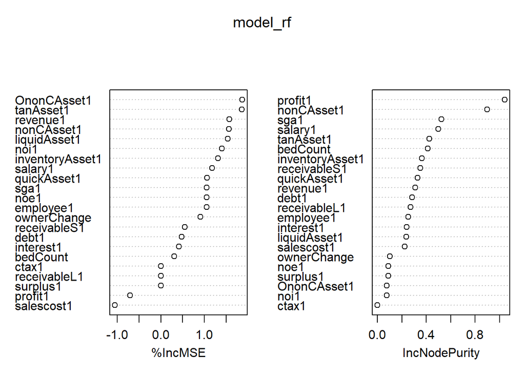

```r
#varImpPlot(model_rf, bg = "pink")
imp <- varImpPlot(model_rf) # let's save the varImp object
```

```r
# this part just creates the data.frame for the plot part

imp <- as.data.frame(imp)
imp$varnames <- rownames(imp) # row names to column
rownames(imp) <- NULL
#imp$var_categ <- rep(1:2, 5) # random var category
colnames(imp)
```

```
## [1] "%IncMSE"       "IncNodePurity" "varnames"
```

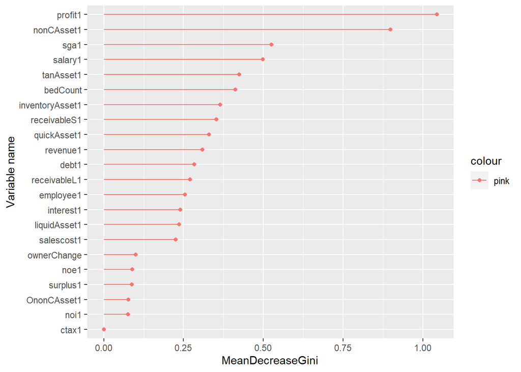

```r
ggplot(imp, aes(x=reorder(varnames, IncNodePurity), y=IncNodePurity, color='pink')) +
  geom_point() +
  geom_segment(aes(x=varnames,xend=varnames,y=0,yend=IncNodePurity)) +
  #scale_color_discrete(name="Variable Group") +
  ylab("MeanDecreaseGini") +
  xlab("Variable name") +
  coord_flip()
```

```r
#ggplot(model_rf, aes(x=reorder(rownames(V),Overall), y=Overall)) +
#geom_point( color="pink", size=4, alpha=0.6)+
#geom_segment( aes(x=rownames(V), xend=rownames(V), y=0, yend=Overall),
#color='pink') +
#xlab('Variable')+
#ylab('Overall Importance')+
#theme_light() +
#coord_flip()
```

#문제1

```r
set.seed(1234)
test_idx=createDataPartition(Boston$medv, p=0.2, times=1, list=FALSE)
X_train=Boston[-test_idx,]
X_test=Boston[test_idx,]
print(paste0('X_train: ', nrow(X_train)))
```

```
## [1] "X_train: 403"
```

```r
print(paste0('X_test: ', nrow(X_test)))
```

```
## [1] "X_test: 103"
```

#문제 2. expand.grid를 이용하여 다음과 같은 데이터 프레임을 만드세요. (데이터 프레임 명: RMSE_rf)

```r
RMSE_rf<-expand.grid( mtry=c(3, 4,5),ntree=c(10, 100, 200),RMSE=NA)
RMSE_rf
```

| mtry | ntree | RMSE |
| --- | --- | --- |
| 3 | 10 | NA |
| 4 | 10 | NA |
| 5 | 10 | NA |
| 3 | 100 | NA |
| 4 | 100 | NA |
| 5 | 100 | NA |
| 3 | 200 | NA |
| 4 | 200 | NA |
| 5 | 200 | NA |

#문제 3. medv를 종속변수로 하는 랜덤포레스트에 대한 5-fold CV 그리드서치를 진행하여 RMSE_rf의 RMSE 변수에 해당 RMSE값을 넣으세요. (이중 for문을 이용하여 직접 코드를 짤 것)

```r
cvstat=numeric(5)
for (i in 1:9){
  for (j in 1:5){
    f<-createFolds(X_train$medv, k=5)#리스트
    ind<-f[[j]]
    cv.train=X_train[-ind,]
    cv.test=X_train[ind,]
    rf=randomForest(medv~., data=cv.train,ntree=RMSE_rf[i,2], mtry=RMSE_rf[i,1])
    yhat=predict(rf,cv.test)
    cvstat[j]<-RMSE(yhat, cv.test$medv)
  }
  RMSE_rf$RMSE[i]<-mean(cvstat)
}

RMSE_rf
```

| mtry | ntree | RMSE |
| --- | --- | --- |
| 3 | 10 | 3.192357 |
| 4 | 10 | 4.006231 |
| 5 | 10 | 3.349909 |
| 3 | 100 | 3.552465 |
| 4 | 100 | 4.199874 |
| 5 | 100 | 3.518738 |
| 3 | 200 | 3.525836 |
| 4 | 200 | 3.017643 |
| 5 | 200 | 3.381702 |

#문제 4. RMSE_rf에서 가장 낮은 RMSE값을 가진 행을 출력하세요.

```r
RMSE_rf[which.min(RMSE_rf$RMSE),]
```

|  | mtry | ntree | RMSE |
| --- | --- | --- | --- |
| 8 | 4 | 200 | 3.017643 |

#문제 5. train set으로 그리드 서치로 나온 가장 좋은 조합의 파라미터의 랜덤포레스트를 학습시킨 후, test set의 RMSE를 구하세요

```r
model_rf = randomForest(medv~., data=X_train, mtry = 4, ntree = 200, importance = T)
model_rf
```

```
##
## Call:
##  randomForest(formula = medv ~ ., data = X_train, mtry = 4, ntree = 200,      importance = T)
##                Type of random forest: regression
##                      Number of trees: 200
## No. of variables tried at each split: 4
##
##           Mean of squared residuals: 11.45013
##                     % Var explained: 86.07
```

```r
pred_values = predict(model_rf,X_test)
#actual_values = X_test$medv
RMSE(pred_values,X_test$medv)
```

```
## [1] 4.281202
```

```r
sqrt(mean((X_test$medv - pred_values)^2))
```

```
## [1] 4.281202
```